# Project Assignment

Martin Holmqvist

2023-06-04

# Introduction

Cancer, and attention-deficit/hyperactivity disorder (adhd) are medical conditions that have a big impact on individuals and society as a whole. Understanding the trends and patterns associated with these conditions are crucial for improving the medical research in these areas and improving the health care in these areas.

Adhd is a disorder that affects attention, behavior control, and impulsivity. Symptoms can vary and can include inattention, impulsivity, and hyperactivity. Diagnosis is based on persistent difficulties since childhood and significant daily life difficulties. Adhd can take different forms predominantly inattentive type (commonly referred to as ADD) and predominantly hyperactive-impulsive type. Individuals with Adhd can also experience additional challenges like autism spectrum disorders, learning difficulties, anxiety, and depression (Region Uppsala, 2023).

Breast cancer is the most common cancer among women in Sweden, with 8 000 women and 60 men diagnosed every year. The Swedish mammography program has improved detection and treatment, leading to higher survival rates. Symptoms include breast lumps, skin changes, and nipple abnormalities (Bröstcancerförbundet, 2023).

Kidney cancer is a disease that starts in the cells of the kidneys. It is one of the most common types of cancer, typically affecting older people. Kidney cancer can have various types, with renal cell carcinoma being the most common. Early detection and treatment play a crucial role in improving outcomes for patients (Internetmedicin, 2023).

To be able to learn more about these medical conditions it is interesting to study if there is any differences between men and women and the amount of cases. It is also interesting to investigate how the development of the conditions has been over time. There are many ways of doing this but some examples are regression analysis, t-test and chi-square tests.

## Research questions

The research questions that will be investigated are:

1. What is the trend of breast cancer cases in Sweden between the years 1970-2019?
2. Is there an association in kidney cancer between gender and different years?
3. Is there a difference in the amount of children that consumes adhd medicine?
4. Is there a difference in the amount of children that consumes adhd medicine between regions and different years?

# Method

The different data sets used in this report has been gathered from socialstyrelsen in Sweden which is a trusted government agency (Socialstyrelsen, 2019).

To begin with the report analyses the first research question, how many people per 100 000 inhabitants in Sweden that has breast cancer over time, the data from socialstyrelsen contains data from 1970 to 2019 (Socialstyelsen, 2022). This analysis will be done by doing a time-series regression analysis to see how the development of breast cancer has been throughout these years. This is important since we then can analyse and see if there is any trends or such that we can take into consideration fort the future.

The second part we will analyse research question 2, with a data set that has information on how many people per 100 000 inhabitants that has kidney cancer over time in Sweden (Socialstyelsen, 2022). We will do a chi-square test to study if there is any association between each gender and the amount of cases at the start of each decade, and the time frame is between 1970 to 2010. The reason why it is a good idea to measure this every tenth year is to reduce the amount of autocorrelation in the test. If we would measure and compare every year same individuals would probably occur in both years but likely not every ten year. This is important since we can then determine if the amount of cases for each gender differs between each deacde which can then lead to further analysis and help future health care.

# Results

*In this section of the thesis the results will be presented, divided into three parts. The first part will show the results from the breast cancer study and hence the answer the first research question, the second part shows the results from the kidney cancer study and answer the second research question will be answered and the third part shows the results from the adhd consumer study where the third and fourth reserach question will be answered.*

## Breast cancer

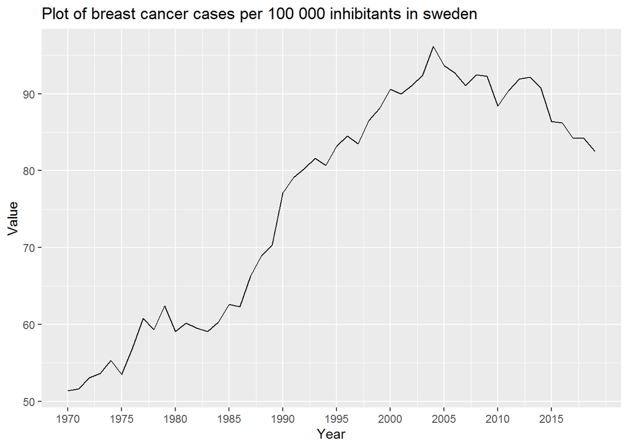

Figure 1: plot of breast cancer cases per 100 000 inhibitants in Sweden over time.

Figure 1 shows how the development of how many inhabitants per 100 000 people that has breast cancer in Sweden. It is clear to see that the amount of cases has increased throughout the years and had the peak at 2005. However after 2005 the amount of cases has decreased.

Table 1: Summary of Regression on people with breast cancer per 100 000 inhibitants between 1970 and 2019

|  | Estimate | Standard Error | t value | Pr(>\|t\|) |  |
| --- | --- | --- | --- | --- | --- |
| (Intercept) | -1,754.115 | 126.488 | -13.868 | 0.0000 | *** |
| years | 0.918 | 0.063 | 14.471 | 0.0000 | *** |

Signif. codes: 0 <= '***' < 0.001 < '**' < 0.01 < '*' < 0.05  
Residual standard error: 6.471 on 48 degrees of freedom  
Multiple R-squared: 0.8135, Adjusted R-squared: 0.8096  
F-statistic: 209.4 on 48 and 1 DF, p-value: 0.0000

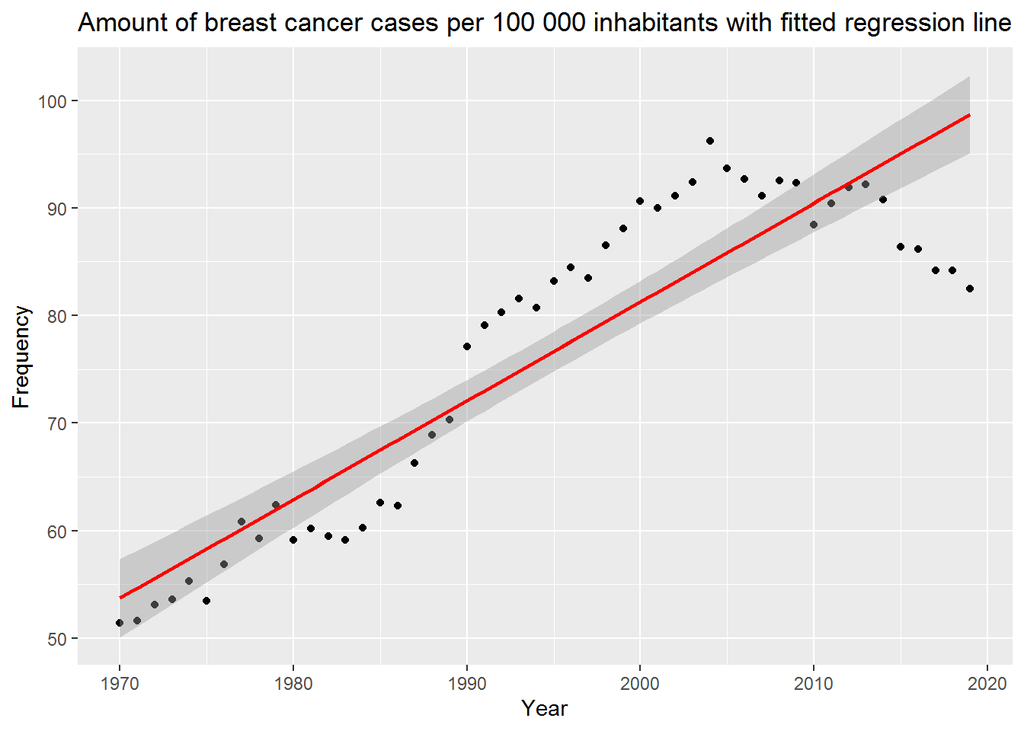

Figure 2: Amount of breast cancer cases per 100 000 inhibitants with fitted regression line.

Table 1 shows a summary of the regression line shown in figure 2. It should be interpreted in a way that for each year the expected increase of inhabitants with breast cancer per 100 000 inhabitants is 0.91. This is visualized in figure 2 where the fitted line is plotted along with the observations. The data seems to follow a linear trend until 2005. Then it seems like a linear model is not suitable to predict the values after 2005 since the trend seems to be negative instead of positive after that.

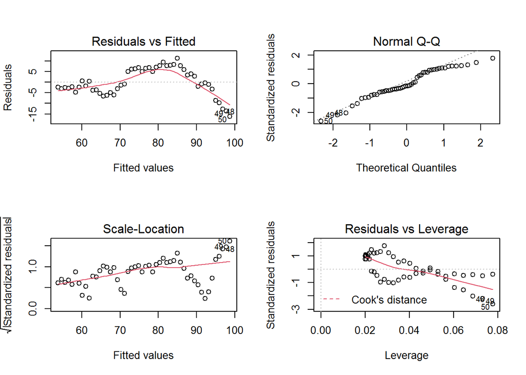

Figure 3: diagnostic plots of regression line in table 1

Figure 3 shows diagnostic plots of the regression from table 1, we can see that the observations are most likely not coming from a normal distribution so that has to be in consideration when interpreting the results. It can be noted that the residuals gets larger after 2010. This is where the values start be decrease and the trend becomes negative.

## Kidney cancer

Table 2: Contingency table of kidney cancer between time and gender

|  | 1970 | 1980 | 1990 | 2000 | 2010 |
| --- | --- | --- | --- | --- | --- |
| Men | 603 | 769 | 688 | 576 | 761 |
| Woman | 489 | 501 | 514 | 408 | 432 |

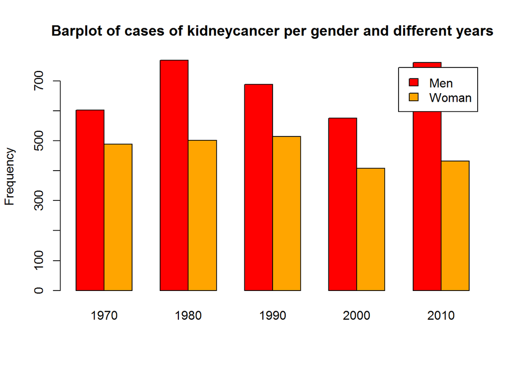

Figure 4: Barplot of cases of kidneycancer per gender and different years.

Table 2 and figure 4 shows how many men and women per 100 000 people that suffered from kidney cancer at the start of each decade from 1970 to 2010. It can be seen that most men suffers from kidney cancer for every year but the difference is bigger or smaller for each year. The year 2000 is the year where the amount of cases are the lowest for both men and women. It would be interesting to perform a chi-square test to see if there is any association in kidney cancer between men and women.

Table 3: Chi-square test of association in kidney cancer between different years and gender.

| statistic | p.value | parameter | method |
| --- | --- | --- | --- |
| 20.6 | 0.0004*** | 4 | Pearson's Chi-squared test |

Signif. codes: 0 <= '***' < 0.001 < '**' < 0.01 < '*' < 0.05

Table 4: Expected frequencies from the test in table 3.

|  | 1970 | 1980 | 1990 | 2000 | 2010 |
| --- | --- | --- | --- | --- | --- |
| Men | 646.1 | 751.5 | 711.2 | 582.2 | 705.9 |
| Woman | 445.9 | 518.5 | 490.8 | 401.8 | 487.1 |

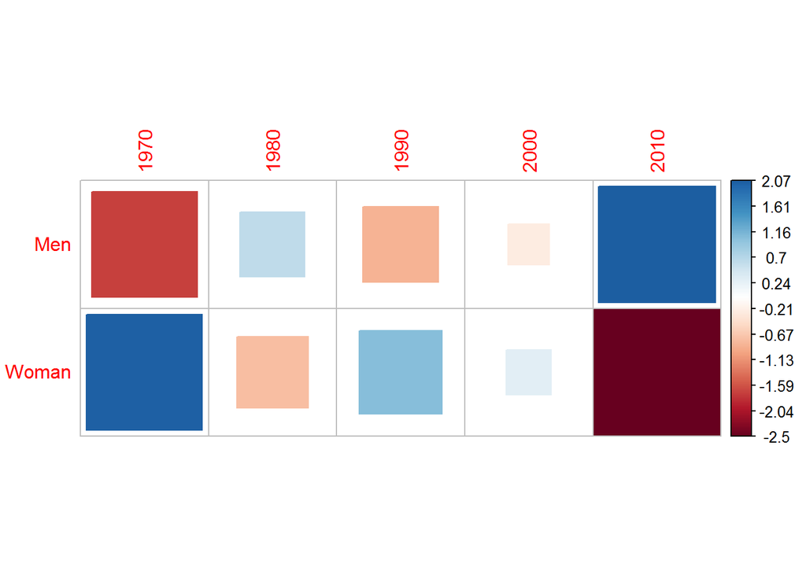

Figure 5, correlationplot of residuals from the chi-square test performed in table 3.

Table 4 shows the expected values that we would expect if there was no association between gender and year. In the following chi-square test we can see if the association is significant.

Table 3 shows the output when performing a chi-square test of the data set with 4 degrees of freedom with the following hypothesizes:

$H_0$: There is no association in kidney cancer cases between gender and year

$H_1$: There is an association in kidney cancer cases between gender and year

We will perform the test with a 5% significance level.

Since we perform a chi-square test or test statistic is:

$$\begin{equation}
\chi^2 = \sum\frac{(observed - expected)^2}{expected}
\end{equation}$$

In table 3 we hence observe a test-statistic of 20.61 which is equal to a p-value of 0.00038 which means that we reject the null hypothesis that there is no association in kidney cancer cases between gender and year.

## Adhd over time

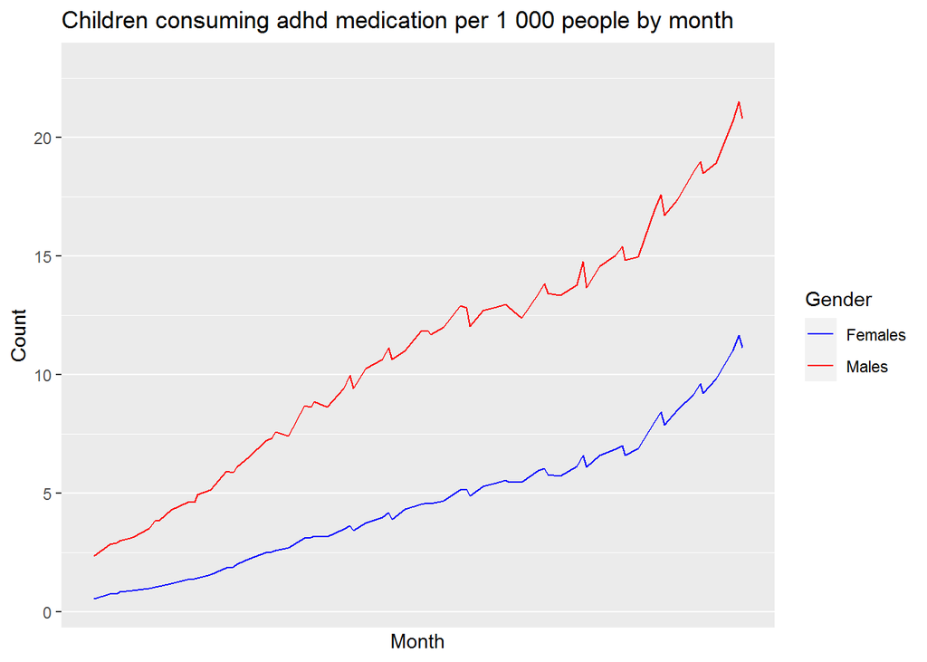

Figure 6: Children consuming adhd medication per 1 000 people by month.

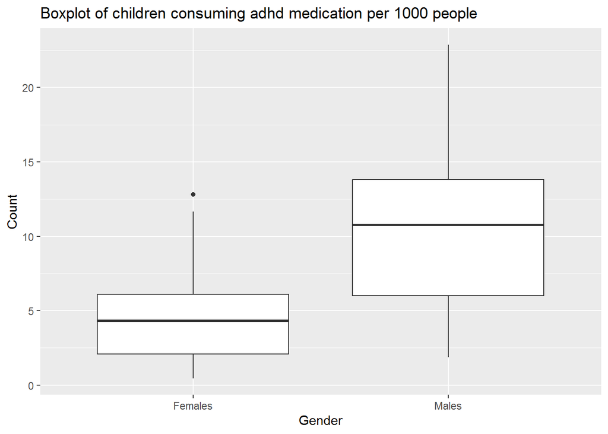

Figure 7: Boxplot of children consuming adhd medication per 1000 people

| Measure | Males | Females |
| --- | --- | --- |
| Mean | 10.47 | 4.46 |
| Median | 10.78 | 4.32 |
| Standard Deviation | 5.05 | 2.82 |

Figure 6 shows a plot on how many men and women between the age of 0-17 per 1000 inhabitants that consumes adhd medication per month. It can visually be seen that more males consume this medicine compared to women for all months. In figure 7 we can also see that the variation is larger for men compared to women and the median is higher for men which is confirmed in table 5 where we can see that the standard deviation is 5.05 for men and 2.82 for women. A paired non parametric test would be appropriate to test if the difference in adhd medication per 1000 people for people between 0-17 years old is significant between genders. Since the observations are most likely not independent since many people are likely to consume medication for many years, a regular t-test would not be suitable since that assumption is hence violated. Wilcoxons paired signed rank test is a more robust test that is more suitable for this data.

Table 6: Results Wilcoxons signed rank sum test of means between gender, regarding the number of children consuming adhd medication

| statistic | p.value | method | alternative |
| --- | --- | --- | --- |
| 21,528.0 | 0.0000*** | Wilcoxon signed rank test with continuity correction | two.sided |

Signif. codes: 0 <= '***' < 0.001 < '**' < 0.01 < '*' < 0.05

Table 6 shows the output when performing a Wilcoxons signed rank test of the data set with the following hypothesizes:

$H_0$: There is no difference of the amount of inhabitants that consumes adhd medication per 1000 people within the ages 0-17 between gender.

$H_1$: There is a difference of the amount of inhabitants that consumes adhd medication per 1000 people within the ages 0-17 between gender.

The test statistic is hence:

$W = min(W+, W-)$

It has been stated that male children consumes more adhd medicine, but to be able to see if there is any significant difference of children that consumes adhd medication between different regions in Sweden.

Table 7, summary of regression over cildren that consumes adhd medicin per 1000 people, and the regions Stockholm, Uppsala and Örebro

|  | Estimate | Standard Error | t value | Pr(>\|t\|) |  |
| --- | --- | --- | --- | --- | --- |
| (Intercept) | 5.412 | 0.240 | 22.596 | 0.0000 | *** |
| RegionStockholm | 1.898 | 0.339 | 5.603 | 0.0000 | *** |
| RegionUppsala | 2.998 | 0.339 | 8.851 | 0.0000 | *** |

Signif. codes: 0 <= '***' < 0.001 < '**' < 0.01 < '*' < 0.05  
Residual standard error: 3.213 on 537 degrees of freedom  
Multiple R-squared: 0.1299, Adjusted R-squared: 0.1267  
F-statistic: 40.1 on 537 and 2 DF, p-value: 0.0000

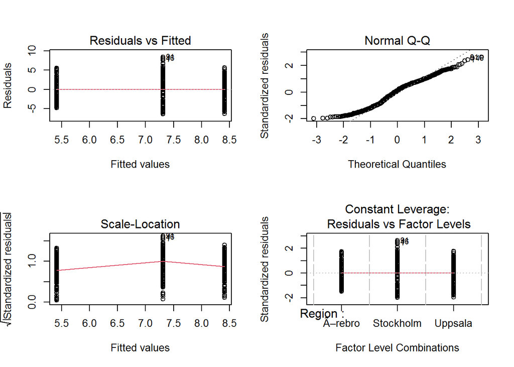

Figure 8:Diagnostics plot from regression in table 7.

Table 7 shows the output from a linear regression where adhd per 1000 people from the age 0-17 is the dependent variable and region is the explainable variable. It is noticeable that all standard deviations are close to each other which means that the spread is similar which is confirmed from. the diagnostics plots in figure 8. It the same plot we can also see that one could argue that the data is not exactly normally distributed but is not far from it. But this is worth having in mind when interpreting the results.

Table 8, Anova analysis on regression over cildren that consumes adhd medicin per 1000 people and the different regions Stockholm, Uppsala and Örebro

|  | Sum Sq | Df | F value | Pr(>F) |
| --- | --- | --- | --- | --- |
| Region | 828.0 | 2.0 | 40.1 | 0.0 |
| Residuals | 5,544.7 | 537.0 |  |  |

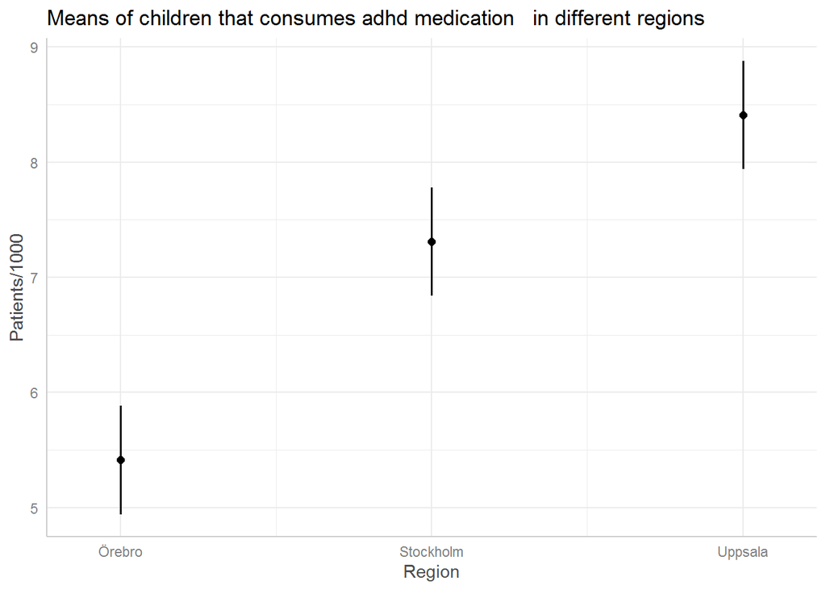

Figure 9: Means of children that consumes adhd medication per 1000 people in different region with 95% confidence interval.

|  | Value | Df | Sum of Sq | F | Pr(>F) |
| --- | --- | --- | --- | --- | --- |
| Örebro-Stockholm | -1.897722 | 1 | 324.1215 | 31.39095 | 0.0000001 |
| Örebro-Uppsala | -2.998056 | 1 | 808.9503 | 78.34630 | 0.0000000 |
| Stockholm-Uppsala | -1.100333 | 1 | 108.9660 | 10.55328 | 0.0012323 |
| Residuals | NA | 537 | 5544.6951 | NA | NA |

When performing a post-hoc analysis in table 10 of the anova we can see that none of the means are the same with very low p-values.

To answer the fourth research question a twoway anova analysis is appropriate. The data has been split up into three time ranges to measure this, the first one is between 2006 and 2010, the second is 2011-2015 and the third is 2016-2020.

|  | Estimate | Standard Error | t value | Pr(>\|t\|) |  |
| --- | --- | --- | --- | --- | --- |
| (Intercept) | 2.376 | 0.189 | 12.553 | 0.0000 | *** |
| RegionStockholm | 0.383 | 0.268 | 1.432 | 0.1527 |  |
| RegionUppsala | 2.534 | 0.268 | 9.466 | 0.0000 | *** |
| YearRange2011-2015 | 3.628 | 0.268 | 13.554 | 0.0000 | *** |
| YearRange2016-2020 | 5.479 | 0.268 | 20.470 | 0.0000 | *** |
| RegionStockholm:YearRange2011-2015 | 1.301 | 0.379 | 3.436 | 0.0006 | *** |
| RegionUppsala:YearRange2011-2015 | 0.840 | 0.379 | 2.218 | 0.0269 |  |
| RegionStockholm:YearRange2016-2020 | 3.242 | 0.379 | 8.565 | 0.0000 | *** |
| RegionUppsala:YearRange2016-2020 | 0.552 | 0.379 | 1.459 | 0.1451 |  |

Signif. codes: 0 <= '***' < 0.001 < '**' < 0.01 < '*' < 0.05  
Residual standard error: 1.466 on 531 degrees of freedom  
Multiple R-squared: 0.8209, Adjusted R-squared: 0.8182  
F-statistic: 304.2 on 531 and 8 DF, p-value: 0.0000

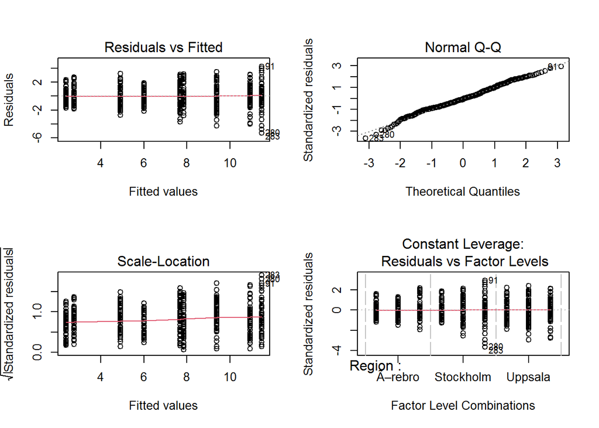

Table 12, Anova analysis on regression from table 11.

|  | Sum Sq | Df | F value | Pr(>F) |
| --- | --- | --- | --- | --- |
| Region | 828.0 | 2.0 | 192.6 | 0.0 |
| YearRange | 4,206.7 | 2.0 | 978.5 | 0.0 |
| Region:YearRange | 196.6 | 4.0 | 22.9 | 0.0 |
| Residuals | 1,141.4 | 531.0 |  |  |

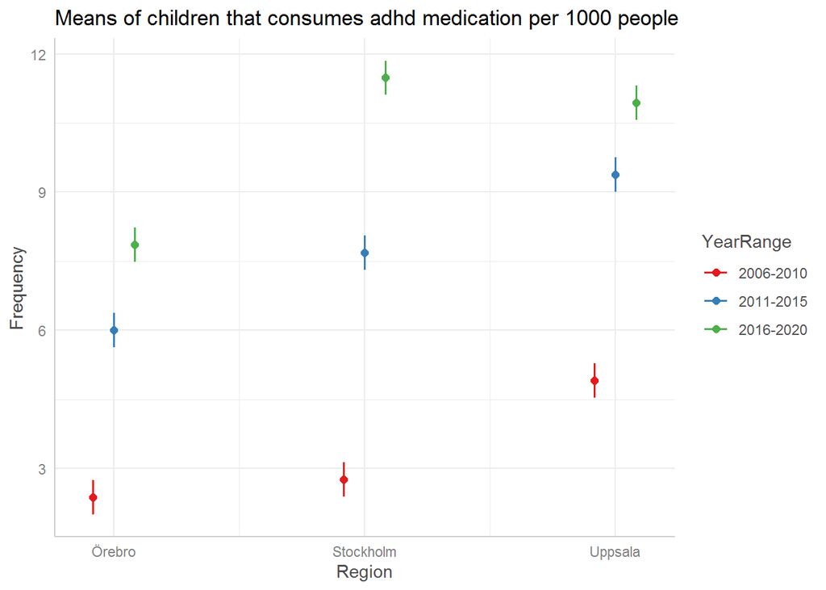

Figure 10: Means of children that consumes adhd medication per 1000 people in different region and in different time ranges with 95% confidence interval.

In table 12 an anova analysis has been done where we can see that the observed p-values for the hypothesizes that all the means are the same for the different regions, time ranges and regions and time ranges are the same is close to zero. Which means that we can conclude that the means differs between time range and region. This can visually be seen in figure 10, but it can visually be seen that for example the means in Stockholm and Örebro in 2006-2010 is close to each other.

Table 13. Pairwise tests between Regions in different timeranges on means in adhd medication, adjustment = Holms test.

|  | Value | Df | Sum of Sq | F | Pr(>F) |
| --- | --- | --- | --- | --- | --- |
| Örebro-Stockholm : 2006-2010 | -0.3833333 | 1 | 4.408333 | 2.050750 | 0.1527196 |
| Örebro-Uppsala : 2006-2010 | -2.5340000 | 1 | 192.634680 | 89.613381 | 0.0000000 |
| Stockholm-Uppsala : 2006-2010 | -2.1506667 | 1 | 138.761013 | 64.551427 | 0.0000000 |
| Örebro-Stockholm : 2011-2015 | -1.6840000 | 1 | 85.075680 | 39.577086 | 0.0000000 |
| Örebro-Uppsala : 2011-2015 | -3.3738333 | 1 | 341.482541 | 158.857195 | 0.0000000 |
| Stockholm-Uppsala : 2011-2015 | -1.6898333 | 1 | 85.666101 | 39.851749 | 0.0000000 |
| Örebro-Stockholm : 2016-2020 | -3.6258333 | 1 | 394.400021 | 183.474333 | 0.0000000 |
| Örebro-Uppsala : 2016-2020 | -3.0863333 | 1 | 285.763603 | 132.936825 | 0.0000000 |
| Stockholm-Uppsala : 2016-2020 | 0.5395000 | 1 | 8.731808 | 4.062024 | 0.0887224 |
| Residuals | NA | 531 | 1141.448007 | NA | NA |

# Discussion

## Discussion regarding breastcancer results

The results from the regression analysis made in the breast cancer section indicated on that for each year we can expect the amount of people that suffers from breast cancer per 100 000 inhabitants to rise with 0.918 people. That is almost an increase of 1 person per year that gets diagnosed with this disease. This is in that the observed p-value is close to 0 which means that the coefficient is significantly different from 0 and we can conclude that the variable year has an effect on the amount of breast cancer cases. In figure 2 however we can see that the increase on breast cancer cases increases for every year until 2005 where it then decreases. This trend is not captured by the regression line that projects an increase but the trend after 2005 is negative, however it flattens the regression line somewhat. Hence it would have been perfect to analyse this data set with linear regression until the year of 2005 but now it seems like the data follows some sort of polynomial pattern with a maximum. The results shows however that there has been a big increase in breast cancer cases between 1970-2005 and the Swedish mammography program has halted this trend. But if these treatments starts failing and the cases increases again this linear regression is of good use. It is also of good use to in general measure how the development has been but a recommendation would be to fit some polynomial line instead.

## Discussion regarding adhd medication results

The results from the amount of adhd medication for children states that there are significantly more male children that consumes adhd medication in the time period 2006-2023 according to the wilcoxons signed rank test. One could argue that a t-test would be appropriate but since the assumption of independence of violated the results would be skewed. We can also see that the median is higher for men as well as the standard deviation. This is important information since we can now assume that male children often is in need of adhd medication which means that measures can be taken at schools for example and start an investigation for adhd for male children if they seem to show characteristics of adhd.

For the twoway anova analysis the means in the regions was measured in different time ranges. The results indicated that the means was not the same for all regions in all year ranges as expected. The post-hoc analysis however showed that we cannot reject the null hypothesis that the mean in Stockholm in the year range 2016-2020 and the mean in Uppsala in the same year range are the same. This gives an indication that Stockholm might have a higher mean in the upcoming year range which is valuable information since Stockholm historically always has had a lower mean in children consuming adhd medication. The posthoc analysis also shows that the null hypothesis that the mean in Örebro and Stockholm in the year range 2006-2010 is the same cannot be rejected. This analysis gives a great opportunity to see if different ways of working has had an effect of the mean adhd consumers in a region depending on changes has been done or not. This is however something that this report cannot analyse but this is however a good basis for such an analysis.

# Conclusion

To answer the first research question we can conclude that the trend of breast cancer cases between 1970-2019 has significantly increased. We can however see that the positive trend has in later years turned negative. This makes linear regression a sub-optimal tool to analyse the trend.

For the second research question we can see an association in kidney cancer between gender and the years 1970, 1980, 1990, 2000 and 2010. Hopefully these results is generalized for different years but further research needs to be done.

For the third research question we can now say that there is a significant difference in children that consumes adhd medicine between gender where male children consume significantly more.

For the fourth research question we can say that there is a difference in the amount of children that consumes adhd medication per 1000 people between the regions Stockholm, Uppsala and Örebro. It can also be stated that the mean is not the same for all the regions in the time ranges 2006-2010, 2011-2015 and 2016-2020. We can not however reject that the mean for Örebro and Stockholm in the time range 2006-2010 are the same. The same conclusion goes for Stockholm and Uppsala in the time range 2016-2020. The rest of the regions and time ranges are not equal.

# References

Adhd, Region Uppsala (2023) https://regionuppsala.se/infoteket/hamta-kunskap/fakta-om-funktionsnedsattningar/adhd/ (accessed 11 may)

Vad är bröstcancer? Bröstcancerförbundet (2023) https://brostcancerforbundet.se/om-brostcancer/vad-ar-brostcancer/ (accessed 10 may)

Njurcancer, Internetmedicin (2023) https://www.internetmedicin.se/behandlingsoversikter/onkologi/njurcancer/ (accessed 10 may)

Statistical databases, Socialstyrelsen (2019) https://www.socialstyrelsen.se/en/statistics-and-data/statistics/statistical-databases/ (accessed 9 may)

Statistical database cancer, Socialstyelsen (2022) https://sdb.socialstyrelsen.se/if_can/val_eng.aspx (accessed 9 may)